# Coverage-Guided Constraint Fuzzing for RISC Zero

## Executive Summary

**What changed:** From random mutation scheduling to a **Discounted-UCB bandit scheduler** that uses constraint-coverage feedback (touch, failure-context, Z events) to guide mutation selection.

**What we can now measure per mutation:**

- **Touched constraints** (local): which constraint sites were active during witness generation
- **Failing constraint contexts** (local): which `(constraint_loc, major, minor)` triples reported non-zero residuals
- **Post-local rejection (Z events)**: mutations passing all local checks but rejected at verification — failure in non-instrumented checks (global constraints, permutation arguments)

**Campaigns compared:**

[output not shown]

**Limitations:** Only local constraints instrumented. Z = "post-local rejection," not a specific global constraint ID.

```python
import sys, os
sys.path.insert(0, os.path.abspath(os.path.join(os.getcwd(), '..', '..')))

import matplotlib.pyplot as plt
import matplotlib.ticker as ticker
import seaborn as sns
import numpy as np
import pandas as pd
from collections import Counter, defaultdict
import math

from a4.standalone.tests.analyze_campaign import (
    parse_terminal, RunRecord,
    compute_cumulative_metrics, compute_cumulative_from_db,
    compute_auc_normalized, compute_t80,
)

sns.set_theme(style='whitegrid', font_scale=1.1)
plt.rcParams['figure.figsize'] = (14, 6)
plt.rcParams['figure.dpi'] = 100

PROJECT_ROOT = os.path.abspath(os.path.join(os.getcwd(), '..', '..'))
UNIFORM_TERMINAL = os.path.join(PROJECT_ROOT, 'uniform_1000_output.txt')
BANDIT32_TERMINAL = '/root/.cursor/projects/root-arguzz/terminals/633840.txt'
UNIFORM_DB = os.path.join(PROJECT_ROOT, 'uniform_baseline_1000.db')
BANDIT32_DB = os.path.join(PROJECT_ROOT, 'a4_coverage.db')
BANDIT32_CAMPAIGN_ID = 57

u_runs, u_meta = parse_terminal(UNIFORM_TERMINAL)
b_runs, b_meta = parse_terminal(BANDIT32_TERMINAL)

u_all = [r for r in u_runs if not r.is_pilot]
b_pilot = [r for r in b_runs if r.is_pilot]
b_bandit = [r for r in b_runs if not r.is_pilot]

u_df = pd.DataFrame([vars(r) for r in u_all])
u_df['idx'] = range(len(u_df))
b_df = pd.DataFrame([vars(r) for r in b_bandit])
b_df['idx'] = range(len(b_df))

SHORT = {
    'COMP_OUT_MOD': 'COMP', 'LOAD_VAL_MOD': 'LOAD', 'STORE_OUT_MOD': 'STORE',
    'PRE_EXEC_REG_MOD': 'PRE_REG', 'INSTR_TYPE_MOD': 'ITYPE',
    'MEM_VAL_MOD': 'MEM', 'INSTR_WORD_MOD_FULL': 'IWORD_F',
    'INSTR_WORD_MOD_SUR': 'IWORD_S',
}
u_df['kind_short'] = u_df['kind'].map(SHORT)
b_df['kind_short'] = b_df['kind'].map(SHORT)
KIND_ORDER = ['IWORD_S', 'IWORD_F', 'ITYPE', 'PRE_REG', 'COMP', 'MEM', 'LOAD', 'STORE']

u_db_cm = compute_cumulative_from_db(UNIFORM_DB)
b_db_cm = compute_cumulative_from_db(BANDIT32_DB, campaign_id=BANDIT32_CAMPAIGN_ID)

u_cm = compute_cumulative_metrics(u_all)
b_cm = compute_cumulative_metrics(b_bandit)

print(f'Uniform:   {len(u_all)} runs')
print(f'Bandit-32: {len(b_pilot)} pilot + {len(b_bandit)} bandit = {len(b_runs)} total')
```

```
Uniform:   1000 runs
Bandit-32: 50 pilot + 946 bandit = 996 total
```

## Section B: Did We Explore the Constraint Space Better?

Four cumulative coverage metrics: **Uniform (red dashed)** vs **Bandit-32 (blue solid)**. Failure-context and family metrics from SQLite (authoritative counts); Z and crashes from terminal.

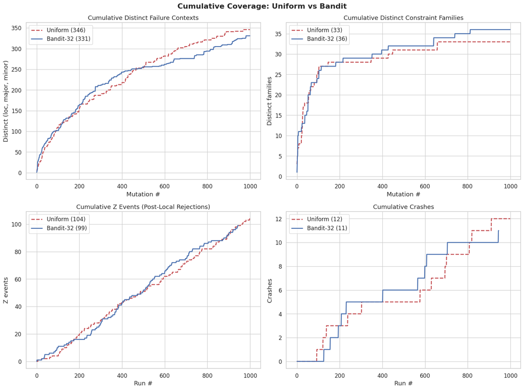

```
             Metric  Uni final  Ban final  Uni AUC  Ban AUC  Uni t80  Ban t80
   Failure contexts        346        331    0.683    0.697      569      620
Constraint families         33         36    0.889    0.849      104      217
           Z events        104         99    0.488    0.496      828      717
```

```python
fig, axes = plt.subplots(2, 2, figsize=(16, 12))
fig.suptitle('Cumulative Coverage: Uniform vs Bandit', fontsize=16, fontweight='bold')

ax = axes[0, 0]
ax.plot(range(len(u_db_cm['cum_fail_contexts'])), u_db_cm['cum_fail_contexts'],
        'r--', lw=2, label=f'Uniform ({u_db_cm["cum_fail_contexts"][-1]})')
ax.plot(range(len(b_db_cm['cum_fail_contexts'])), b_db_cm['cum_fail_contexts'],
        'b-', lw=2, label=f'Bandit-32 ({b_db_cm["cum_fail_contexts"][-1]})')
ax.set_title('Cumulative Distinct Failure Contexts')
ax.set_xlabel('Mutation #'); ax.set_ylabel('Distinct (loc, major, minor)'); ax.legend()

ax = axes[0, 1]
ax.plot(range(len(u_db_cm['cum_families'])), u_db_cm['cum_families'],
        'r--', lw=2, label=f'Uniform ({u_db_cm["cum_families"][-1]})')
ax.plot(range(len(b_db_cm['cum_families'])), b_db_cm['cum_families'],
        'b-', lw=2, label=f'Bandit-32 ({b_db_cm["cum_families"][-1]})')
ax.set_title('Cumulative Distinct Constraint Families')
ax.set_xlabel('Mutation #'); ax.set_ylabel('Distinct families'); ax.legend()

ax = axes[1, 0]
ax.plot(u_df['idx'], np.cumsum(u_df['Z']),
        'r--', lw=2, label=f'Uniform ({int(u_df["Z"].sum())})')
ax.plot(b_df['idx'], np.cumsum(b_df['Z']),
        'b-', lw=2, label=f'Bandit-32 ({int(b_df["Z"].sum())})')
ax.set_title('Cumulative Z Events (Post-Local Rejections)')
ax.set_xlabel('Run #'); ax.set_ylabel('Z events'); ax.legend()

ax = axes[1, 1]
ax.plot(u_df['idx'], np.cumsum((u_df['outcome']=='CRASH').astype(int)),
        'r--', lw=2, label=f'Uniform ({int((u_df["outcome"]=="CRASH").sum())})')
ax.plot(b_df['idx'], np.cumsum((b_df['outcome']=='CRASH').astype(int)),
        'b-', lw=2, label=f'Bandit-32 ({int((b_df["outcome"]=="CRASH").sum())})')
ax.set_title('Cumulative Crashes')
ax.set_xlabel('Run #'); ax.set_ylabel('Crashes'); ax.legend()

plt.tight_layout()
plt.show()

rows = []
for name, uc, bc in [
    ('Failure contexts', u_db_cm['cum_fail_contexts'], b_db_cm['cum_fail_contexts']),
    ('Constraint families', u_db_cm['cum_families'], b_db_cm['cum_families']),
    ('Z events', list(np.cumsum(u_df['Z']).astype(int)), list(np.cumsum(b_df['Z']).astype(int))),
]:
    rows.append({'Metric': name,
        'Uni final': uc[-1], 'Ban final': bc[-1],
        'Uni AUC': round(compute_auc_normalized(uc),3),
        'Ban AUC': round(compute_auc_normalized(bc),3),
        'Uni t80': compute_t80(uc), 'Ban t80': compute_t80(bc)})
print(pd.DataFrame(rows).to_string(index=False))
```

## Section C: What Did the Bandit Learn?

The reward function identifies **structural differences** between mutation kinds. Two high-value regimes emerge: instruction-type mutations (touch/failure novelty) and instruction-word mutations (Z events).

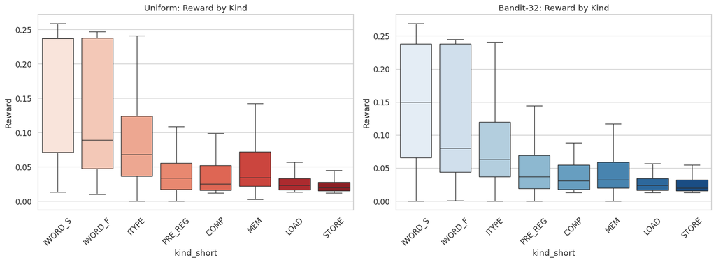

```
      Kind   Uniform    Bandit
   IWORD_S     0.165     0.154
   IWORD_F     0.131     0.129
     ITYPE     0.089     0.088
   PRE_REG     0.047     0.055
      COMP     0.043     0.049
       MEM     0.061     0.049
      LOAD     0.029     0.032
     STORE     0.027     0.029
```

```python
fig, axes = plt.subplots(1, 2, figsize=(16, 6))
sns.boxplot(data=u_df, x='kind_short', y='reward', order=KIND_ORDER,
            ax=axes[0], palette='Reds', showfliers=False)
axes[0].set_title('Uniform: Reward by Kind'); axes[0].set_ylabel('Reward')
axes[0].tick_params(axis='x', rotation=45)
sns.boxplot(data=b_df, x='kind_short', y='reward', order=KIND_ORDER,
            ax=axes[1], palette='Blues', showfliers=False)
axes[1].set_title('Bandit-32: Reward by Kind'); axes[1].set_ylabel('Reward')
axes[1].tick_params(axis='x', rotation=45)
plt.tight_layout(); plt.show()

print(f'{"Kind":>10s}  {"Uniform":>8s}  {"Bandit":>8s}')
for k in KIND_ORDER:
    um = u_df[u_df['kind_short']==k]['reward'].mean()
    bm = b_df[b_df['kind_short']==k]['reward'].mean()
    print(f'{k:>10s}  {um:8.3f}  {bm:8.3f}')
```

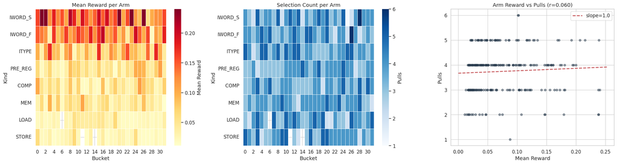

```python
T, B_count = 3930, 32
B = math.ceil(T / B_count)
b_df['bucket'] = b_df['step'] // B

fig, axes = plt.subplots(1, 3, figsize=(22, 6))
pivot_r = b_df.pivot_table(values='reward', index='kind_short', columns='bucket', aggfunc='mean').reindex(KIND_ORDER)
sns.heatmap(pivot_r, ax=axes[0], cmap='YlOrRd', annot=False, linewidths=0.5, linecolor='white',
            cbar_kws={'label': 'Mean Reward'})
axes[0].set_title('Mean Reward per Arm'); axes[0].set_xlabel('Bucket'); axes[0].set_ylabel('Kind')

pivot_c = b_df.pivot_table(values='reward', index='kind_short', columns='bucket', aggfunc='count').reindex(KIND_ORDER)
sns.heatmap(pivot_c, ax=axes[1], cmap='Blues', annot=False, linewidths=0.5, linecolor='white',
            cbar_kws={'label': 'Pulls'})
axes[1].set_title('Selection Count per Arm'); axes[1].set_xlabel('Bucket'); axes[1].set_ylabel('Kind')

arm_s = b_df.groupby(['kind_short','bucket']).agg(mean_reward=('reward','mean'),count=('reward','count')).reset_index()
axes[2].scatter(arm_s['mean_reward'], arm_s['count'], alpha=0.5, s=30, c='#2c3e50')
z = np.polyfit(arm_s['mean_reward'], arm_s['count'], 1)
axes[2].plot(np.linspace(0, arm_s['mean_reward'].max()*1.05, 100),
             np.poly1d(z)(np.linspace(0, arm_s['mean_reward'].max()*1.05, 100)),
             'r--', lw=2, label=f'slope={z[0]:.1f}')
rc = np.corrcoef(arm_s['mean_reward'], arm_s['count'])[0,1]
axes[2].set_title(f'Arm Reward vs Pulls (r={rc:.3f})'); axes[2].set_xlabel('Mean Reward')
axes[2].set_ylabel('Pulls'); axes[2].legend()
plt.tight_layout(); plt.show()
```

```python
arm_d = b_df.groupby(['kind_short','bucket']).agg(
    pulls=('reward','count'), mean_r=('reward','mean'),
    z_cnt=('Z','sum'), mean_nf=('n_fail','mean'), mean_Q=('Q','mean')).reset_index()
arm_d['z_rate'] = arm_d['z_cnt'] / arm_d['pulls']
top15 = arm_d.nlargest(15, 'mean_r')
print('=== TOP 15 ARMS BY MEAN REWARD ===')
print(f'{"Kind":>10s} {"Bkt":>4s} {"Pulls":>5s} {"Mean r":>7s} {"Z rate":>7s} {"nf":>5s} {"Q":>5s}')
for _, r in top15.iterrows():
    print(f'{r["kind_short"]:>10s} {int(r["bucket"]):4d} {int(r["pulls"]):5d} '
          f'{r["mean_r"]:7.3f} {r["z_rate"]:7.1%} {r["mean_nf"]:5.1f} {r["mean_Q"]:5.2f}')
```

```
=== TOP 15 ARMS BY MEAN REWARD ===
      Kind  Bkt Pulls  Mean r  Z rate    nf     Q
   IWORD_S    1     3   0.240  100.0%   0.0  1.00
   IWORD_S   20     5   0.239   60.0%   0.4  0.89
   IWORD_S    2     2   0.238  100.0%   0.0  1.00
   IWORD_S   26     2   0.238  100.0%   0.0  1.00
   IWORD_S   23     3   0.238  100.0%   0.0  1.00
   IWORD_S    8     5   0.215   80.0%   0.2  0.94
   IWORD_F   16     5   0.206   80.0%   0.2  0.94
   IWORD_S   15     4   0.200   75.0%   0.2  0.93
   IWORD_F   24     4   0.196   75.0%   0.2  0.93
   IWORD_S   17     4   0.194   50.0%   0.5  0.86
   IWORD_S   11     5   0.192   80.0%  32.8  0.80
   IWORD_S    4     3   0.181   66.7%   0.3  0.91
   IWORD_F   13     4   0.180   50.0%   0.8  0.81
   IWORD_F   31     3   0.180   66.7%   0.7  0.84
   IWORD_S    9     2   0.179    0.0%   1.0  0.72
```

## Section D: Why Z Events Matter

**Z events** = mutations with no local constraint failures, yet proof rejected. Failure is in non-instrumented logic (likely global constraints).

For soundness-bug hunting, Z events are closest to the acceptance boundary.

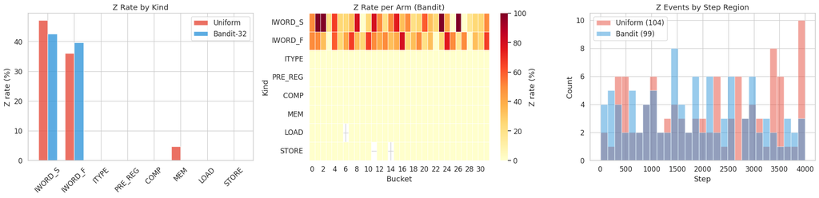

```
                        Uniform  Bandit-32
Z events                    104         99
Z rate                    10.4%      10.5%
Z mean reward             0.239      0.239
Non-Z mean reward         0.054      0.056
Z / non-Z ratio            4.4x       4.3x
```

```python
fig, axes = plt.subplots(1, 3, figsize=(20, 5))

ax = axes[0]
x = np.arange(len(KIND_ORDER)); w = 0.35
for i, (lbl, df, c) in enumerate([('Uniform', u_df, '#e74c3c'), ('Bandit-32', b_df, '#3498db')]):
    zk = df.groupby('kind_short')['Z'].sum().reindex(KIND_ORDER, fill_value=0)
    tk = df.groupby('kind_short').size().reindex(KIND_ORDER, fill_value=1)
    ax.bar(x + (-w/2 if i==0 else w/2), zk/tk*100, w, label=lbl, color=c, alpha=0.8)
ax.set_xticks(x); ax.set_xticklabels(KIND_ORDER, rotation=45)
ax.set_title('Z Rate by Kind'); ax.set_ylabel('Z rate (%)'); ax.legend()

ax = axes[1]
bz = b_df.copy(); bz['bucket'] = bz['step'] // math.ceil(3930/32)
pz = bz.pivot_table(values='Z', index='kind_short', columns='bucket', aggfunc='mean').reindex(KIND_ORDER)*100
sns.heatmap(pz, ax=ax, cmap='YlOrRd', annot=False, linewidths=0.5, linecolor='white',
            cbar_kws={'label': 'Z rate (%)'})
ax.set_title('Z Rate per Arm (Bandit)'); ax.set_xlabel('Bucket'); ax.set_ylabel('Kind')

ax = axes[2]
bins = np.linspace(0, 4000, 30)
ax.hist(u_df[u_df['Z']==1]['step'], bins=bins, alpha=0.5, color='#e74c3c', label=f'Uniform ({int(u_df["Z"].sum())})')
ax.hist(b_df[b_df['Z']==1]['step'], bins=bins, alpha=0.5, color='#3498db', label=f'Bandit ({int(b_df["Z"].sum())})')
ax.set_title('Z Events by Step Region'); ax.set_xlabel('Step'); ax.set_ylabel('Count'); ax.legend()
plt.tight_layout(); plt.show()

uz, bz_ = int(u_df['Z'].sum()), int(b_df['Z'].sum())
print(f'{"":20s} {"Uniform":>10s} {"Bandit-32":>10s}')
print(f'{"Z events":20s} {uz:10d} {bz_:10d}')
print(f'{"Z rate":20s} {uz/len(u_df)*100:9.1f}% {bz_/len(b_df)*100:9.1f}%')
uzr = u_df[u_df['Z']==1]['reward'].mean(); bzr = b_df[b_df['Z']==1]['reward'].mean()
unr = u_df[(u_df['Z']==0)&(u_df['outcome']!='CRASH')]['reward'].mean()
bnr = b_df[(b_df['Z']==0)&(b_df['outcome']!='CRASH')]['reward'].mean()
print(f'{"Z mean reward":20s} {uzr:10.3f} {bzr:10.3f}')
print(f'{"Non-Z mean reward":20s} {unr:10.3f} {bnr:10.3f}')
print(f'{"Z / non-Z ratio":20s} {uzr/max(unr,1e-9):9.1f}x {bzr/max(bnr,1e-9):9.1f}x')
```

## Section E: Quality Control — Crashes and Cascades

The Q multiplier penalizes crashes (Q=0) and cascade failures. This prevents the bandit from chasing garbage.

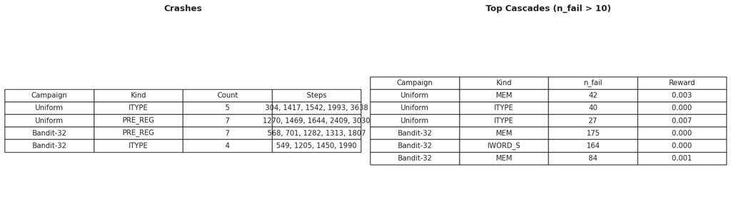

```python
fig, axes = plt.subplots(1, 2, figsize=(16, 5))
ax = axes[0]; ax.axis('off')
cd = []
for lbl, df in [('Uniform', u_df), ('Bandit-32', b_df)]:
    cr = df[df['outcome']=='CRASH']
    if len(cr) > 0:
        for k in cr['kind'].unique():
            kc = cr[cr['kind']==k]
            cd.append([lbl, SHORT.get(k,k), len(kc), ', '.join(str(s) for s in sorted(kc['step'].unique())[:5])])
if cd:
    t = ax.table(cellText=cd, colLabels=['Campaign','Kind','Count','Steps'], loc='center', cellLoc='center')
    t.auto_set_font_size(False); t.set_fontsize(11); t.scale(1, 1.5)
ax.set_title('Crashes', fontweight='bold', pad=20)

ax = axes[1]; ax.axis('off')
cr2 = []
for lbl, df in [('Uniform', u_df), ('Bandit-32', b_df)]:
    tc = df[df['n_fail']>10].nlargest(3, 'n_fail')
    for _, r in tc.iterrows():
        cr2.append([lbl, r['kind_short'], int(r['n_fail']), f'{r["reward"]:.3f}'])
if cr2:
    t = ax.table(cellText=cr2, colLabels=['Campaign','Kind','n_fail','Reward'], loc='center', cellLoc='center')
    t.auto_set_font_size(False); t.set_fontsize(11); t.scale(1, 1.5)
ax.set_title('Top Cascades (n_fail > 10)', fontweight='bold', pad=20)
plt.tight_layout(); plt.show()
```

## Key Takeaways

### Next Steps

- Reduced-arm bandit (B=16, 128 arms): demonstrate exploitation
- Z signature analysis (Phase III.0): cluster Z by rejection error
- Global constraint instrumentation (Phase III.1): replace Z with explicit global contexts

# Appendix: Algorithm Specification

## Reward: $r = \min(1, Q \cdot S)$

$$S = \frac{a_{T_n} T_{\text{new}} + a_{T_r} T_{\text{rare}} + a_{F_n} F_{\text{new}} + a_{F_r} F_{\text{rare}} + a_Z Z}{\sum a_i}$$

- $T_{\text{new}} = 1 - e^{-\Delta_T / \tau_T}$, $F_{\text{new}} = 1 - e^{-\Delta_F / \tau_F}$
- $T_{\text{rare}} = \frac{1}{K_T}\sum_{\text{top-}K_T} (1+f_T[i])^{-1/2}$, $F_{\text{rare}} = \frac{1}{K_F}\sum_{\text{top-}K_F} (1+f_F[c])^{-1/2}$
- $Z = \mathbb{1}[\text{REJECTED} \wedge \text{proof\_gen} \wedge d_{\text{fail}}=0]$

## Quality: $Q = Q_{\text{dist}} \times Q_{\text{rep}}$

- $Q_{\text{dist}} = e^{-d_{\text{fail}}/\tau_d}$, $Q_{\text{rep}} = \begin{cases}1 & r_{\text{rep}} \leq r_0 \\ e^{-(r_{\text{rep}}-r_0)/\tau_r} & \text{else}\end{cases}$

## Bandit: Discounted UCB

$$\text{UCB}_a = \hat{\mu}_a + c\sqrt{\frac{\ln N_{\text{tot}}}{N_a}}, \quad N_a \leftarrow N_a \gamma^{\Delta t}$$

Weights: $a_{T_n}\!=\!1, a_{T_r}\!=\!0.25, a_{F_n}\!=\!1, a_{F_r}\!=\!1, a_Z\!=\!1$. $c\!=\!0.25$, $\gamma\!\approx\!0.997$.

```python
print('=== CAMPAIGN COMPARISON ===')
print(f'{"":25s} {"Uniform":>10s} {"Bandit-32":>10s}')
print(f'{"Total mutations":25s} {len(u_all):10d} {len(b_runs):10d}')
print(f'{"  (pilot)":25s} {0:10d} {len(b_pilot):10d}')
print(f'{"  (main)":25s} {len(u_all):10d} {len(b_bandit):10d}')
print(f'{"REJECTED":25s} {len(u_df[u_df["outcome"]=="REJECTED"]):10d} {len(b_df[b_df["outcome"]=="REJECTED"]):10d}')
print(f'{"CRASH":25s} {len(u_df[u_df["outcome"]=="CRASH"]):10d} {len(b_df[b_df["outcome"]=="CRASH"]):10d}')
print(f'{"Distinct fail contexts":25s} {u_db_cm["cum_fail_contexts"][-1]:10d} {b_db_cm["cum_fail_contexts"][-1]:10d}')
print(f'{"Distinct families":25s} {u_db_cm["cum_families"][-1]:10d} {b_db_cm["cum_families"][-1]:10d}')
print(f'{"Z events":25s} {int(u_df["Z"].sum()):10d} {int(b_df["Z"].sum()):10d}')
print(f'{"Mean reward":25s} {u_df["reward"].mean():10.4f} {b_df["reward"].mean():10.4f}')
```

```
=== CAMPAIGN COMPARISON ===
                             Uniform  Bandit-32
Total mutations                 1000        996
  (pilot)                          0         50
  (main)                        1000        946
REJECTED                         988        935
CRASH                             12         11
Distinct fail contexts           346        331
Distinct families                 33         36
Z events                         104         99
Mean reward                   0.0726     0.0742
```